# Bike Sharing Dataset Exploration

## Preliminary Wrangling

This data set includes information about individual rides made in a bike-sharing system covering the greater San Francisco Bay area.

```python
# import all packages and set plots to be embedded inline
import numpy as np
import pandas as pd
import matplotlib.pyplot as plt
import seaborn as sb

%matplotlib inline
```

> Load in your dataset and describe its properties through the questions below. Try and motivate your exploration goals through this section.

```python
df = pd.read_csv('201902-fordgobike-tripdata.csv')
pd.options.display.max_rows = 200
pd.options.display.max_columns = 200
df.head(10)
```

|  | duration_sec | start_time | end_time | start_station_id | start_station_name | start_station_latitude | start_station_longitude | end_station_id | end_station_name | end_station_latitude | end_station_longitude | bike_id | user_type | member_birth_year | member_gender | bike_share_for_all_trip |
| --- | --- | --- | --- | --- | --- | --- | --- | --- | --- | --- | --- | --- | --- | --- | --- | --- |
| 0 | 52185 | 2019-02-28 17:32:10.1450 | 2019-03-01 08:01:55.9750 | 21.0 | Montgomery St BART Station (Market St at 2nd St) | 37.789625 | -122.400811 | 13.0 | Commercial St at Montgomery St | 37.794231 | -122.402923 | 4902 | Customer | 1984.0 | Male | No |
| 1 | 42521 | 2019-02-28 18:53:21.7890 | 2019-03-01 06:42:03.0560 | 23.0 | The Embarcadero at Steuart St | 37.791464 | -122.391034 | 81.0 | Berry St at 4th St | 37.775880 | -122.393170 | 2535 | Customer | NaN | NaN | No |
| 2 | 61854 | 2019-02-28 12:13:13.2180 | 2019-03-01 05:24:08.1460 | 86.0 | Market St at Dolores St | 37.769305 | -122.426826 | 3.0 | Powell St BART Station (Market St at 4th St) | 37.786375 | -122.404904 | 5905 | Customer | 1972.0 | Male | No |
| 3 | 36490 | 2019-02-28 17:54:26.0100 | 2019-03-01 04:02:36.8420 | 375.0 | Grove St at Masonic Ave | 37.774836 | -122.446546 | 70.0 | Central Ave at Fell St | 37.773311 | -122.444293 | 6638 | Subscriber | 1989.0 | Other | No |
| 4 | 1585 | 2019-02-28 23:54:18.5490 | 2019-03-01 00:20:44.0740 | 7.0 | Frank H Ogawa Plaza | 37.804562 | -122.271738 | 222.0 | 10th Ave at E 15th St | 37.792714 | -122.248780 | 4898 | Subscriber | 1974.0 | Male | Yes |
| 5 | 1793 | 2019-02-28 23:49:58.6320 | 2019-03-01 00:19:51.7600 | 93.0 | 4th St at Mission Bay Blvd S | 37.770407 | -122.391198 | 323.0 | Broadway at Kearny | 37.798014 | -122.405950 | 5200 | Subscriber | 1959.0 | Male | No |
| 6 | 1147 | 2019-02-28 23:55:35.1040 | 2019-03-01 00:14:42.5880 | 300.0 | Palm St at Willow St | 37.317298 | -121.884995 | 312.0 | San Jose Diridon Station | 37.329732 | -121.901782 | 3803 | Subscriber | 1983.0 | Female | No |
| 7 | 1615 | 2019-02-28 23:41:06.7660 | 2019-03-01 00:08:02.7560 | 10.0 | Washington St at Kearny St | 37.795393 | -122.404770 | 127.0 | Valencia St at 21st St | 37.756708 | -122.421025 | 6329 | Subscriber | 1989.0 | Male | No |
| 8 | 1570 | 2019-02-28 23:41:48.7900 | 2019-03-01 00:07:59.7150 | 10.0 | Washington St at Kearny St | 37.795393 | -122.404770 | 127.0 | Valencia St at 21st St | 37.756708 | -122.421025 | 6548 | Subscriber | 1988.0 | Other | No |
| 9 | 1049 | 2019-02-28 23:49:47.6990 | 2019-03-01 00:07:17.0250 | 19.0 | Post St at Kearny St | 37.788975 | -122.403452 | 121.0 | Mission Playground | 37.759210 | -122.421339 | 6488 | Subscriber | 1992.0 | Male | No |

```python
print(df.shape)
df.info(show_counts=True, max_cols=81)
```

```
(183412, 16)
<class 'pandas.core.frame.DataFrame'>
RangeIndex: 183412 entries, 0 to 183411
Data columns (total 16 columns):
 #   Column                   Non-Null Count   Dtype
---  ------                   --------------   -----
 0   duration_sec             183412 non-null  int64
 1   start_time               183412 non-null  object
 2   end_time                 183412 non-null  object
 3   start_station_id         183215 non-null  float64
 4   start_station_name       183215 non-null  object
 5   start_station_latitude   183412 non-null  float64
 6   start_station_longitude  183412 non-null  float64
 7   end_station_id           183215 non-null  float64
 8   end_station_name         183215 non-null  object
 9   end_station_latitude     183412 non-null  float64
 10  end_station_longitude    183412 non-null  float64
 11  bike_id                  183412 non-null  int64
 12  user_type                183412 non-null  object
 13  member_birth_year        175147 non-null  float64
 14  member_gender            175147 non-null  object
 15  bike_share_for_all_trip  183412 non-null  object
dtypes: float64(7), int64(2), object(7)
memory usage: 22.4+ MB
```

```python
df.describe()
```

|  | duration_sec | start_station_id | start_station_latitude | start_station_longitude | end_station_id | end_station_latitude | end_station_longitude | bike_id | member_birth_year |
| --- | --- | --- | --- | --- | --- | --- | --- | --- | --- |
| count | 183412.000000 | 183215.000000 | 183412.000000 | 183412.000000 | 183215.000000 | 183412.000000 | 183412.000000 | 183412.000000 | 175147.000000 |
| mean | 726.078435 | 138.590427 | 37.771223 | -122.352664 | 136.249123 | 37.771427 | -122.352250 | 4472.906375 | 1984.806437 |
| std | 1794.389780 | 111.778864 | 0.099581 | 0.117097 | 111.515131 | 0.099490 | 0.116673 | 1664.383394 | 10.116689 |
| min | 61.000000 | 3.000000 | 37.317298 | -122.453704 | 3.000000 | 37.317298 | -122.453704 | 11.000000 | 1878.000000 |
| 25% | 325.000000 | 47.000000 | 37.770083 | -122.412408 | 44.000000 | 37.770407 | -122.411726 | 3777.000000 | 1980.000000 |
| 50% | 514.000000 | 104.000000 | 37.780760 | -122.398285 | 100.000000 | 37.781010 | -122.398279 | 4958.000000 | 1987.000000 |
| 75% | 796.000000 | 239.000000 | 37.797280 | -122.286533 | 235.000000 | 37.797320 | -122.288045 | 5502.000000 | 1992.000000 |
| max | 85444.000000 | 398.000000 | 37.880222 | -121.874119 | 398.000000 | 37.880222 | -121.874119 | 6645.000000 | 2001.000000 |

```python
df.duplicated().sum()
```

```
0
```

```python
df.isnull().sum()
```

```
duration_sec                  0
start_time                    0
end_time                      0
start_station_id            197
start_station_name          197
start_station_latitude        0
start_station_longitude       0
end_station_id              197
end_station_name            197
end_station_latitude          0
end_station_longitude         0
bike_id                       0
user_type                     0
member_birth_year          8265
member_gender              8265
bike_share_for_all_trip       0
dtype: int64
```

```python
df['member_gender'].unique()
```

```
array(['Male', nan, 'Other', 'Female'], dtype=object)
```

```python
df['bike_share_for_all_trip'].unique()
```

```
array(['No', 'Yes'], dtype=object)
```

```python
df['bike_id'].nunique()
```

```
4646
```

```python
df['start_station_id'].nunique()
```

```
329
```

```python
df['end_station_id'].nunique()
```

```
329
```

```python
df['user_type'].unique()
```

```
array(['Customer', 'Subscriber'], dtype=object)
```

```python
df['start_time'] = pd.to_datetime(df['start_time'])
df['start_time'].min(), df['start_time'].max()
```

```
(Timestamp('2019-02-01 00:00:20.636000'),
 Timestamp('2019-02-28 23:59:18.548000'))
```

```python
df['end_time'] = pd.to_datetime(df['end_time'])
df['end_time'].min(), df['end_time'].max()
```

```
(Timestamp('2019-02-01 00:04:52.058000'),
 Timestamp('2019-03-01 08:01:55.975000'))
```

### What is the structure of your dataset?

The data consists of 183412 rides and 16 variables of 4646 bikes over the period of one month (from 1 Feb 2019 to 1 March 2019) from and to 329 stations. The data has no duplicates but has some missing values in the start station, end station, gender and birthdate variables.

### What features in the dataset do you think will help support your investigation into your feature(s) of interest?

I believe the duration of the trip, the start and end times of each trip, the birthdate and user type can be helpful in my investigation.

## Univariate Exploration

> In this section, investigate distributions of individual variables. If you see unusual points or outliers, take a deeper look to clean things up and prepare yourself to look at relationships between variables.

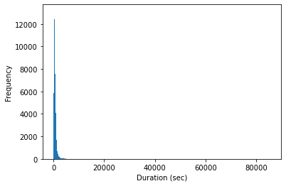

```python
bins = np.arange(df['duration_sec'].min(), df['duration_sec'].max()+50, 50)
plt.hist(df['duration_sec'], bins=bins)
plt.xlabel('Duration (sec)')
plt.ylabel('Frequency');
# plt.axvline(x=df['duration_sec'].mean(), color='red');
```

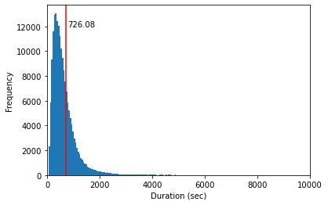

```python
# Zooming in on the main blob of data
bins = np.arange(df['duration_sec'].min(), df['duration_sec'].max()+50, 50)
plt.hist(df['duration_sec'], bins=bins)
plt.xlim([0, 10000])
plt.xlabel('Duration (sec)')
plt.ylabel('Frequency')
plt.axvline(x=df['duration_sec'].mean(), color='red')
plt.text(x=df['duration_sec'].mean()+50, y=12000, s='{:.2f}'.format(df['duration_sec'].mean()));
```

The duration distribution is very very right skewed, with some trips reaching above 85000 seconds. However, the majority of trips took between 62 and 2000 seconds, with the average at 726 seconds.

```python
np.log10(df['duration_sec']).describe()
```

```
count    183412.000000
mean          2.712606
std           0.309396
min           1.785330
25%           2.511883
50%           2.710963
75%           2.900913
max           4.931682
Name: duration_sec, dtype: float64
```

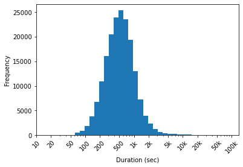

```python
# Zooming in on the main blob of data
bins = 10 ** np.arange(1.785330, 4.931682 + 0.1, 0.1)
plt.hist(df['duration_sec'], bins=bins)
plt.xlabel('Duration (sec)')
plt.ylabel('Frequency')
ticks = [10, 20, 50, 100, 200, 500, 1000, 2000, 5000, 1e4, 2e4, 5e4, 1e5]
labels = ['{}'.format(x) if x < 1000 else '{}k'.format(int(x//1000)) for x in ticks]
plt.xscale('log')
plt.xticks(ticks=ticks, labels=labels, rotation=45);
```

Plotting the duration on a log scale shows that it follows a normal distribution slightly right skewed.

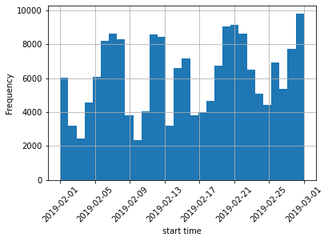

```python
# bins = np.arange(df['start_time'].min(), df['start_time'].max()+50, 50)
plt.hist(df['start_time'], bins=30)
plt.xlabel('start time')
plt.ylabel('Frequency')
plt.xticks(rotation=45)
plt.grid();
```

I would say that there is a repetitive pattern in the starting time from 5-9 Feb and 19-24 Feb. Also, the number of rides reached its maximum by the end of the month. In general, the number of rides seem to increase over the days.

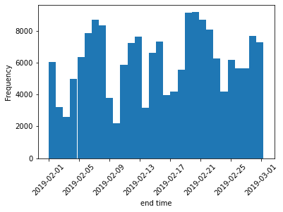

```python
# bins = np.arange(df['start_time'].min(), df['start_time'].max()+50, 50)
plt.hist(df['end_time'], bins=30)
plt.xlabel('end time')
plt.ylabel('Frequency')
plt.xticks(rotation=45);
```

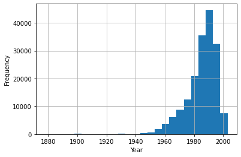

```python
bins = np.arange(df['member_birth_year'].min(), df['member_birth_year'].max()+5, 5)
plt.hist(df['member_birth_year'], bins=bins)
plt.xlabel('Year')
plt.ylabel('Frequency')
plt.grid();
```

The distribution is left skewed which means more of the younger generations from 1980 to 2000 are using the bike sharing service than older generations.

```python
df['member_birth_year'].value_counts().iloc[-20:]
```

```
1900.0    53
1948.0    51
2001.0    34
1943.0    30
1942.0    21
1933.0    20
1946.0    19
1939.0    11
1902.0    11
1941.0     9
1901.0     6
1920.0     3
1938.0     3
1944.0     2
1934.0     2
1928.0     1
1878.0     1
1930.0     1
1910.0     1
1927.0     1
Name: member_birth_year, dtype: int64
```

```python
(df['member_birth_year'] < 1940).sum(), (df['member_birth_year'] < 1901).sum()
```

```
(203, 54)
```

Okay, so there are users who registered their birth year before 1940, which means they were over 80 years old when the data was collected ! Moreover, there are 54 users who registered they were born before 1901 !!! Clearly, some of these values are incorrect.

```python
df['start_dayOfWeek'] = df['start_time'].dt.dayofweek.map({0:'Monday', 1: 'Tuesday', 2:'Wednesday', 3: 'Thursday', 4:'Friday', 5:'Saturday', 6:'Sunday'})
df['end_dayOfWeek'] = df['end_time'].dt.dayofweek.map({0:'Monday', 1: 'Tuesday', 2:'Wednesday', 3: 'Thursday', 4:'Friday', 5:'Saturday', 6:'Sunday'})
```

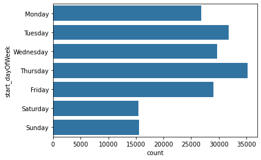

```python
df['start_dayOfWeek'] = df['start_dayOfWeek'].astype(pd.api.types.CategoricalDtype(categories=['Monday','Tuesday','Wednesday','Thursday','Friday','Saturday','Sunday'], ordered=True))
df['end_dayOfWeek'] = df['end_dayOfWeek'].astype(pd.api.types.CategoricalDtype(categories=['Monday','Tuesday','Wednesday','Thursday','Friday','Saturday','Sunday'], ordered=True))
sb.countplot(data=df, y='start_dayOfWeek', color=sb.color_palette()[0]);
```

The day with the highest number of rides is Thursday followed by Tuesday and Wedensday. The days with the least number of rides are in the weekeend: Saturday and Sunday. Maybe rides are made to and from work.

```python
df['start_hour'] = df['start_time'].dt.hour
df['end_hour'] = df['end_time'].dt.hour
```

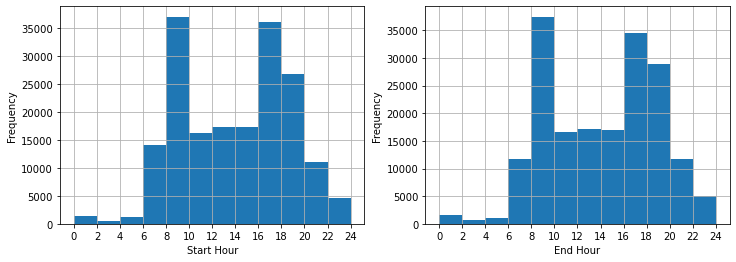

```python
bins = np.arange(0, 25, 2)
plt.figure(figsize=(12, 4))
plt.subplot(121)
plt.hist(df['start_hour'], bins=bins)
plt.xlabel('Start Hour')
plt.ylabel('Frequency')
plt.xticks(list(range(0, 25, 2)))
plt.grid();
plt.subplot(122)
plt.hist(df['end_hour'], bins=bins)
plt.xlabel('End Hour')
plt.ylabel('Frequency')
plt.xticks(list(range(0, 25, 2)))
plt.grid();
```

The hour of day distribution shows a bimodal distribution with one peak from 8 to 10 AM and another from 4 to 6 PM. Maybe these are the rush hours of the day.

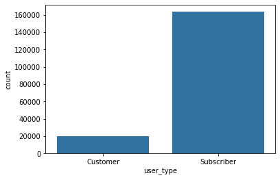

```python
sb.countplot(data=df, x='user_type', color=sb.color_palette()[0]);
```

About 20000 users are customers and 160000 are subscribers.

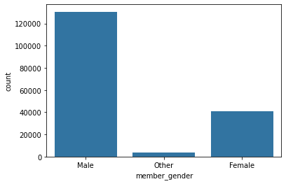

```python
sb.countplot(data=df, x='member_gender', color=sb.color_palette()[0]);
```

The majority of members are males (about 130000 users) followed by females (about 40000 users) and then others.

### Discuss the distribution(s) of your variable(s) of interest. Were there any unusual points? Did you need to perform any transformations?

The distribution of the duration in seconds is highly right skewed. When applying a log transformation on it, it turns to a normal distribution that is slightly right skewed.

### Of the features you investigated, were there any unusual distributions? Did you perform any operations on the data to tidy, adjust, or change the form of the data? If so, why did you do this?

When investigating the distribution of birth year, I found some values at and before 1900 which is clearly incorrect. There are also some suspicious values from 1900 to 1948. No transformation are made on the birth year because the correct birth year is unknown and it might be expensive to remove these outliers.

## Bivariate Exploration

> In this section, investigate relationships between pairs of variables in your data. Make sure the variables that you cover here have been introduced in some fashion in the previous section (univariate exploration).

```python
df['log_duration_sec'] = np.log(df['duration_sec'])
df['age'] = pd.datetime.now().year - df['member_birth_year']
```

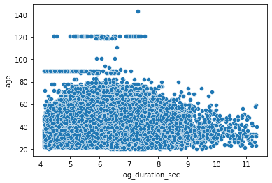

```python
sb.scatterplot(data=df, x = 'log_duration_sec', y='age')
plt.show()
```

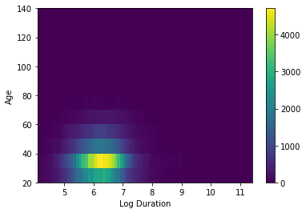

```python
xbins = np.arange(df['log_duration_sec'].min(), df['log_duration_sec'].max()+0.1, 0.1)
ybins = np.arange(20, 140+10, 10)
plt.hist2d(x=df['log_duration_sec'], y=df['age'], bins = [xbins, ybins])
plt.xlabel('Log Duration')
plt.ylabel('Age')
plt.colorbar()
plt.show();
```

The points shows a wider variation in duration taken for younger users than older users. In short, older users seem to take smaller rides than younger users.

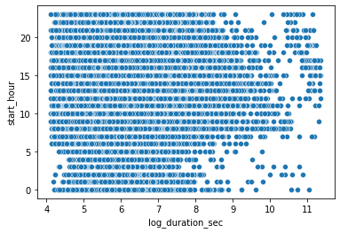

```python
sb.scatterplot(data=df, x = 'log_duration_sec', y='start_hour')
```

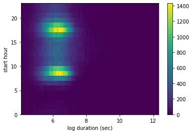

```python
xbins = np.arange(df['log_duration_sec'].min(), df['log_duration_sec'].max()+1, 0.1)
ybins = np.arange(df['start_hour'].min(), df['start_hour'].max()+1, 1)
plt.hist2d(x=df['log_duration_sec'], y=df['start_hour'], bins=[xbins, ybins])
plt.xlabel('log duration (sec)');
plt.ylabel('start hour')
plt.colorbar();
```

From the 2D histogram, it is clear that most rides take place around 8-9 AM and 5-6 PM. Also the duration of rides that happen in the evening take slightly longer than those of the morning. There are also some rides in the middle from 10 AM to 3-4 PM, but almost non before 5 AM.

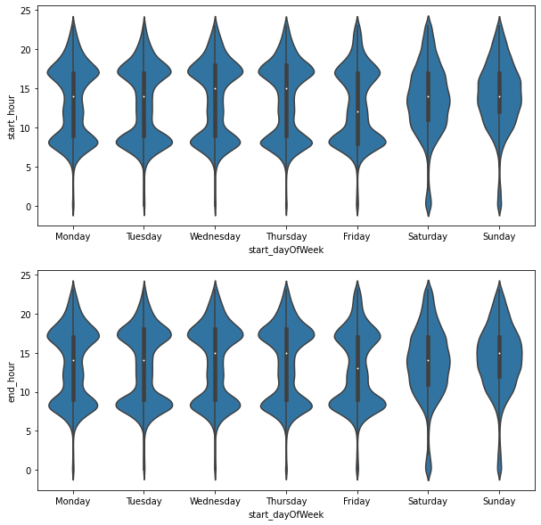

```python
plt.figure(figsize=(10,10))
plt.subplot(211)
sb.violinplot(data=df, x='start_dayOfWeek', y='start_hour', color=sb.color_palette()[0]);
plt.subplot(212)
sb.violinplot(data=df, x='start_dayOfWeek', y='end_hour', color=sb.color_palette()[0]);
```

From the violin plot, it is clear that in working days (from Monday to Friday), the start time of a ride is concentrated around 8-10 AM and 5-7 PM however, in weekend, the distribution is normal peaked at the middle of the day at around 3 PM.

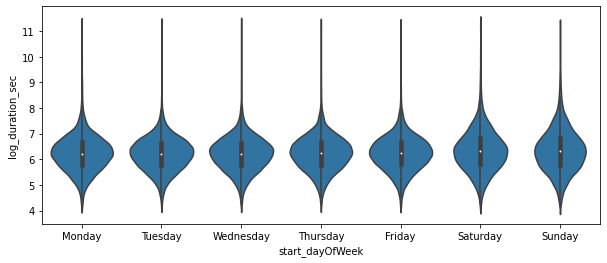

```python
plt.figure(figsize=(10,4))
sb.violinplot(data=df, x='start_dayOfWeek', y='log_duration_sec', color=sb.color_palette()[0]);
```

The distribution of the duration is slightly wider in the weekend than the working days.

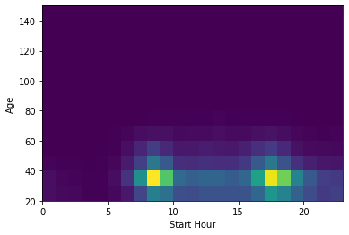

```python
# plt.figure(figsize=(10,4))
xbins = np.arange(df['start_hour'].min(), df['start_hour'].max()+1, 1)
ybins = np.arange(df['age'].min(), df['age'].max()+10, 10)
plt.hist2d(x=df['start_hour'], y=df['age'], bins=[xbins, ybins])
plt.xlabel('Start Hour')
plt.ylabel('Age');
```

Age doesn't affect the start hour of the ride.

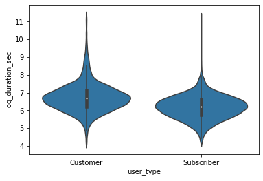

```python
sb.violinplot(data=df, x='user_type', y='log_duration_sec', color=sb.color_palette()[0]);
```

Customers on average take longer rides than Subscribers.

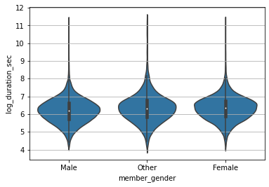

```python
sb.violinplot(data=df, x='member_gender', y='log_duration_sec', color=sb.color_palette()[0])
plt.grid(axis='y');
```

Males, Others and Femals take rides of almost the same length.

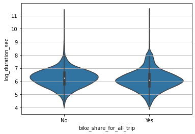

```python
sb.violinplot(data=df, x='bike_share_for_all_trip', y='log_duration_sec', color=sb.color_palette()[0])
plt.grid(axis='y');
```

Rides with no bike share for all trip take longer on average than those with share for all trip.

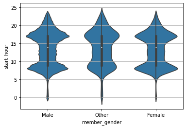

```python
sb.violinplot(data=df, x='member_gender', y='start_hour', color=sb.color_palette()[0])
plt.grid(axis='y');
```

### Talk about some of the relationships you observed in this part of the investigation. How did the feature(s) of interest vary with other features in the dataset?

It was clear that there is a peak in the number of rides daily in the morning and evening except for the weekends, where the distribution of the number of rides was normally distributed. Also, there is a decrease in the duration with the increase of age.

### Did you observe any interesting relationships between the other features (not the main feature(s) of interest)?

It is clear that weekends have different distributions from the working days.

## Multivariate Exploration

> Create plots of three or more variables to investigate your data even further. Make sure that your investigations are justified, and follow from your work in the previous sections.

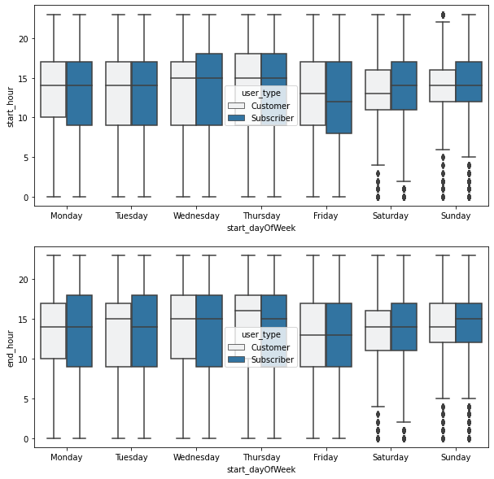

```python
plt.figure(figsize=(10,10))
plt.subplot(211)
sb.boxplot(data=df, x='start_dayOfWeek', y='start_hour', hue='user_type', color=sb.color_palette()[0]);
plt.subplot(212)
sb.boxplot(data=df, x='start_dayOfWeek', y='end_hour', hue='user_type', color=sb.color_palette()[0]);
```

There is almost no difference in the start and end hours for customers and subscribers.

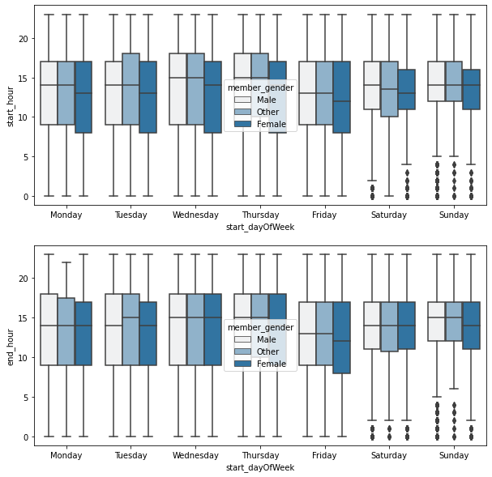

```python
plt.figure(figsize=(10,10))
plt.subplot(211)
sb.boxplot(data=df, x='start_dayOfWeek', y='start_hour', hue='member_gender', color=sb.color_palette()[0]);
plt.subplot(212)
sb.boxplot(data=df, x='start_dayOfWeek', y='end_hour', hue='member_gender', color=sb.color_palette()[0]);
```

Females seem to take rides slightly earlier than males and others.

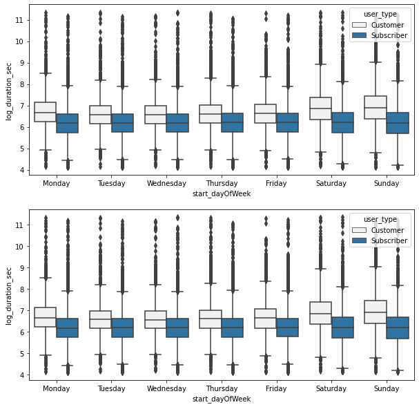

```python
plt.figure(figsize=(10,10))
plt.subplot(211)
sb.boxplot(data=df, x='start_dayOfWeek', y='log_duration_sec', hue='user_type', color=sb.color_palette()[0]);
plt.subplot(212)
sb.boxplot(data=df, x='start_dayOfWeek', y='log_duration_sec', hue='user_type', color=sb.color_palette()[0]);
```

Again, customers seem to take longer rides than subscribers throughout the week especially in weekends.

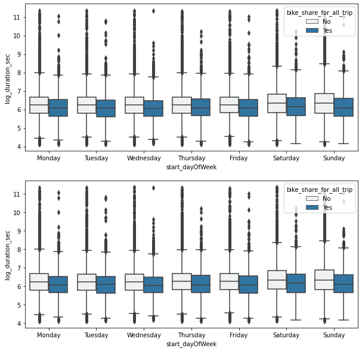

```python
plt.figure(figsize=(10,10))
plt.subplot(211)
sb.boxplot(data=df, x='start_dayOfWeek', y='log_duration_sec', hue='bike_share_for_all_trip', color=sb.color_palette()[0]);
plt.subplot(212)
sb.boxplot(data=df, x='start_dayOfWeek', y='log_duration_sec', hue='bike_share_for_all_trip', color=sb.color_palette()[0]);
```

### Talk about some of the relationships you observed in this part of the investigation. Were there features that strengthened each other in terms of looking at your feature(s) of interest?

Customers seem to take longer rides than subscribers especially in weekends.

### Were there any interesting or surprising interactions between features?

Females seem to take the rides slightly earlier than males!

> At the end of your report, make sure that you export the notebook as an html file from the `File > Download as... > HTML` menu. Make sure you keep track of where the exported file goes, so you can put it in the same folder as this notebook for project submission. Also, make sure you remove all of the quote-formatted guide notes like this one before you finish your report!